# ReproducibleReaerchProject1

rmydeen

12/29/2019

## Assignment Steps

### Read & process data ( Step 1)

1. Read CSV file
2. Process & transform CSV data (Step 1)

### Calculate Total number of steps (Steps 2 & 3)

3. Calculate total number of steps per day
4. Make a histrogram of total number of steps per day ( Step 2)
5. Calculate & report the mean & median of the total number of steps taken per day (Step 3)

### Average Daily Activity Pattern (Steps 4 & 5)

6. Calculate average daily activity pattern
7. Make a time series plot of the 5-minute interval (x-axis) and the average number of steps taken, averaged across all days (y-axis) (Step 4)
8. Find which 5-minute interval, on average across all the days in the dataset, contains the maximum number of steps.(Step 5)

### Impute Missing Values ( Steps 6 & 7 & 8)

9. Calculate and report the total number of missing values in the dataset.
10. Devise a strategy for filling in all of the missing values in the dataset.( Step 6)
11. Make a histogram of the total number of steps taken each day and Calculate and report the mean and median total number of steps taken per day.( Step 7)
12. Make a panel plot containing a time series plot of the 5-minute interval (x-axis) and the average number of steps taken, averaged across all weekday days or weekend days (y-axis). (Step 8)

## R Code Part

```r
#Ingore warnings for Knitr
knitr::opts_chunk$set(warning=FALSE)
library(ggplot2)
library(lubridate)
```

### Step 1 - Code to read and process data

```r
#Following steps to download data and extract
temp <- tempfile()
download.file("https://d396qusza40orc.cloudfront.net/repdata%2Fdata%2Factivity.zip", temp, mode="wb")
unzip(temp, "activity.csv",exdir = "data")
activityData <- read.csv("./data/activity.csv")
unlink(temp)

activityData$date <- as.POSIXct(activityData$date, "%Y-%m-%d")
weekday <- weekdays(activityData$date)
activityData <- cbind(activityData,weekday)
# Dim
dim(activityData)
```

```
## [1] 17568     4
```

```r
# Summary of all activity data
summary(activityData)
```

```
##      steps             date               interval           weekday
##  Min.   :  0.00   Min.   :2012-10-01   Min.   :   0.0   Friday   :2592
##  1st Qu.:  0.00   1st Qu.:2012-10-16   1st Qu.: 588.8   Monday   :2592
##  Median :  0.00   Median :2012-10-31   Median :1177.5   Saturday :2304
##  Mean   : 37.38   Mean   :2012-10-31   Mean   :1177.5   Sunday   :2304
##  3rd Qu.: 12.00   3rd Qu.:2012-11-15   3rd Qu.:1766.2   Thursday :2592
##  Max.   :806.00   Max.   :2012-11-30   Max.   :2355.0   Tuesday  :2592
##  NA's   :2304                                           Wednesday:2592
```

```r
#head
head(activityData)
```

```
##   steps       date interval weekday
## 1    NA 2012-10-01        0  Monday
## 2    NA 2012-10-01        5  Monday
## 3    NA 2012-10-01       10  Monday
## 4    NA 2012-10-01       15  Monday
## 5    NA 2012-10-01       20  Monday
## 6    NA 2012-10-01       25  Monday
```

```r
# Names
names(activityData)
```

```
## [1] "steps"    "date"     "interval" "weekday"
```

### Step 2 - total number of steps per day

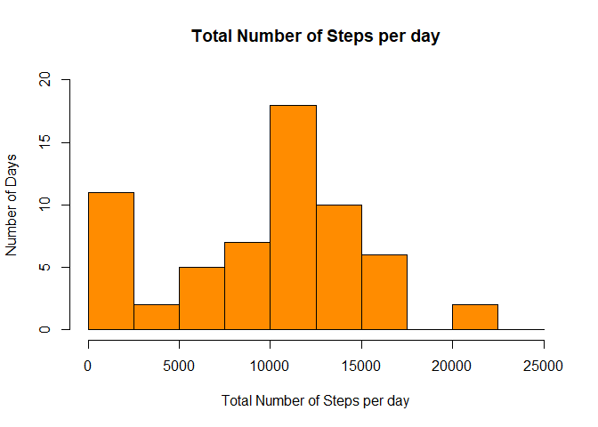

```r
totalStepsPerDay <- with(activityData, aggregate(steps, by = list(date), FUN = sum, na.rm = TRUE))
names(totalStepsPerDay) <- c("date", "steps")

hist(totalStepsPerDay$steps, xlab="Total Number of Steps per day", ylab="Number of Days", main="Total Number of Steps per day",col="darkOrange",ylim = c(0,20), breaks = seq(0,25000, by=2500))
```

### Step 3 - Mean & Median

```r
#Mean of total steps taken per day
mean(totalStepsPerDay$steps)
```

```
## [1] 9354.23
```

```r
# Median of total steps taken per day
median(totalStepsPerDay$steps)
```

```
## [1] 10395
```